# Week2_Homework

Hasan Almekdash

October 23, 2016

# Introduction

Aggregate functions were used as seen below to yield output showing the state code, the sume of fatalities per state, and the month of the year. Moreover, aggregate and plot functions were used to return a plot of fatalities per month.

## Getting the Data Ready

The following command lines were written in order to get the data ready for analysis:

```r
setwd("C:/Users/malmekda/Desktop/R_Session_Di")
setwd("C:/Users/malmekda/Desktop/R_Session_Di")
accident <- read.csv("C:/Users/malmekda/Desktop/R_Session_Di/accident.csv", header=FALSE)
View(accident)
accidents <- read.delim(file="accident.csv", header=T, sep=",")
head(accidents)
```

```
##   STATE ST_CASE VE_TOTAL VE_FORMS PVH_INVL PEDS PERNOTMVIT PERMVIT PERSONS
## 1     1   10001        1        1        0    0          0       1       1
## 2     1   10002        1        1        0    0          0       1       1
## 3     1   10003        1        1        0    0          0       2       2
## 4     1   10004        1        1        0    0          0       1       1
## 5     1   10005        2        2        0    0          0       2       2
## 6     1   10006        1        1        0    0          0       2       2
##   COUNTY CITY DAY MONTH YEAR DAY_WEEK HOUR MINUTE NHS RUR_URB FUNC_SYS
## 1    127    0   1     1 2015        5    2     40   0       1        3
## 2     83    0   1     1 2015        5   22     13   1       1        1
## 3     11    0   1     1 2015        5    1     25   0       1        3
## 4     45    0   4     1 2015        1    0     57   0       1        4
## 5     45 2050   7     1 2015        4    7      9   0       2        3
## 6    111    0   8     1 2015        5    9     59   0       1        5
##   RD_OWNER ROUTE  TWAY_ID          TWAY_ID2 MILEPT LATITUDE LONGITUD
```

[output cut: 27 more lines]

## Showing the Fatalities, Month, and State

Aggregate is a very flexible function that is used in different ways to manupilate data in R. In general, Aggregate structure is : aggregate(formula, data, function). the formula is y~x where y is a numeric variable to be devided and x is the grouping variable. The data in this example is the accident.cvs, and the function needed is the sum of fatalities per month and state (state codes are used instead of state names). Here is the code and its output:

```r
aggregate (FATALS~MONTH+STATE,accidents, FUN = sum)
```

```
##     MONTH STATE FATALS
## 1       1     1     58
## 2       2     1     38
## 3       3     1     70
## 4       4     1     74
## 5       5     1     75
## 6       6     1     66
## 7       7     1     77
## 8       8     1     79
## 9       9     1     78
## 10     10     1     85
## 11     11     1     70
## 12     12     1     79
## 13      1     2      2
## 14      2     2      2
```

[output cut: 594 more lines]

## Fatalities per Month

Another usage for using “aggregate” function (see the explanation of aggregate above). The plot command is used to show MONTH as x and FATALS as y after aggregation. Here is the command line and its output:

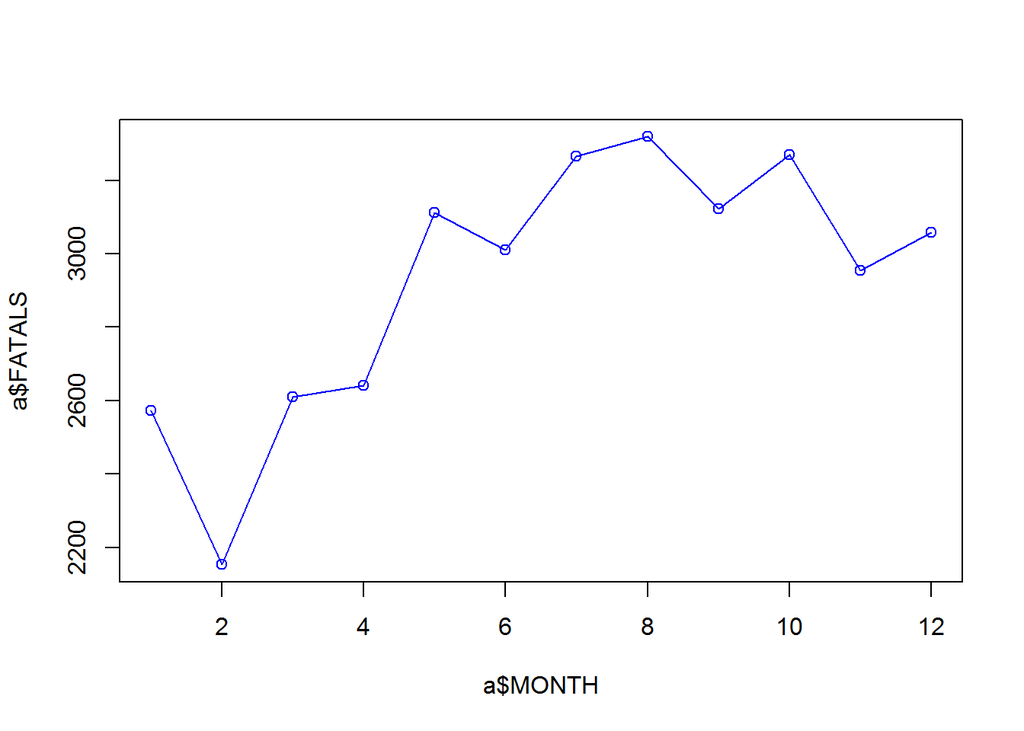

```r
a<-aggregate(FATALS~MONTH, accidents,sum)
plot(a$MONTH,a$FATALS, type='o', col='blue' )
```